# Introduction to R: Why code?

ABC Research Meeting 2026, Cape Town

Author

Pete Laver

Published

November 23, 2026

## 1 Personal experience

edit_note

- Science is hard.
- We aren’t always kind to our future selves.
- It is even harder to be kind to those who follow us.

In this session, we’re going to go on a journey together before we actually get to R.

Let’s start right here in this room.

Raise your hand if you’ve ever opened up your own project notes, your notebook, or your lab notebook for an old analysis or project … and found that you couldn’t recreate the results or even the workflow?

Does anyone want to briefly share about that experience?

Now, raise your hand if you’ve tried to recreate the results or workflow from someone else, but failed to do so.

Does anyone want to share briefly about that?

## 2 Scientific credibility

spellcheck

credibility — trust placed in an institution / researcher / group / finding by the scientific community and the public

Let’s think about the field of scientific research as an institution. For the public to place their trust in science, what percentage of studies do you think should be possible to reproduce or replicate?

Of the study replications and reproductions that have been attempted to date, what percentage do you think have been successful?

African Brain Child | Neurosciences Institute | UCT

## 3 Interactive responses

[figure not shown]

[https://tinyurl.com/4a3wwxpe](https://docs.google.com/forms/d/e/1FAIpQLScoCB8qP_F7_PQibXlbrCcta610dhzCR0mNN62F40K2f-iTGQ/viewform?usp=publish-editor)

African Brain Child | Neurosciences Institute | UCT

## 4 Ideal replication / reproduction rate?

[interactive chart not shown]

African Brain Child | Neurosciences Institute | UCT

## 5 Actual replication / reproduction rate?

[interactive chart not shown]

African Brain Child | Neurosciences Institute | UCT

## 6 Reliability matrix

Data

Same

New

Analysis /  
code

Same

New

Same data,  
same code

New data,  
same code

Same data,  
new code

New data,  
new code

Result

Robust

Replicable

Reproducible

Generalizable

Flanagan, J. 2025. Reproducibility, replicability, robustness, and generalizability in corpus linguistics. International Journal of Corpus Linguistics 30(2):130-149. https://doi.org/10.1075/ijcl.24113.fla

African Brain Child | Neurosciences Institute | UCT

## 7 Reproducibility, gene expression studies

18 papers  
**Same data** (public datasets)  
**Same code** (original analytical pipeline)

[interactive chart not shown]

article

Ioannidis, J., Allison, D., Ball, C. et al. Repeatability of published microarray gene expression analyses. **Nat Genet 41**, 149–155 (2009). https://doi.org/10.1038/ng.295

African Brain Child | Neurosciences Institute | UCT

## 8 Replicability, oncology drug target studies

67 projects  
**New data** (new in-house wet-lab assays)  
**Mixed code** (21% same code, 67% adapted models or assays)

[interactive chart not shown]

article

Prinz, F., Schlange, T. & Asadullah, K. Believe it or not: how much can we rely on published data on potential drug targets?. **Nat Rev Drug Discov 10**, 712 (2011). https://doi.org/10.1038/nrd3439-c1

Bayer HealthCare - projects within Bayer, where results had already been published. The authors from Bayer went back and tried to replicate these studies in-house.

African Brain Child | Neurosciences Institute | UCT

## 9 Replicability, preclinical cancer research studies

53 papers  
**New data** (new cell / animal models)  
**Mixed code** (Same protocols / reagents, some adapted models)

[interactive chart not shown]

article

Begley, C., Ellis, L. Raise standards for preclinical cancer research. **Nature 483**, 531–533 (2012). https://doi.org/10.1038/483531a

Researchers from Amgen looked at 53 landmark papers published in high-impact journals. Replicated 6, and failed to replicate 47. When Amgen could not reproduce the results, they contacted the original authors, discussed the discrepancies, and even repeated the experiments in the original authors’ laboratories using the exact same reagents—yet the findings still largely failed to hold up.

African Brain Child | Neurosciences Institute | UCT

## 10 Replicability, psychology studies

100 papers  
**New data** (new participants)  
**Same code** (original materials and protocols)

[interactive chart not shown]

article

Open Science Collaboration, Estimating the reproducibility of psychological science. **Science 349**, aac4716 (2015). DOI:10.1126/science.aac4716

African Brain Child | Neurosciences Institute | UCT

## 11 Replicability, other fields

47 papers, scoping review (health sciences, economics, biomedicine, education)  
**Mixed data** (20% re-analysis, ~80% some new trials)  
**Mixed code** (some re-analysis, some adapted protocols)

[interactive chart not shown]

article

Cobey, KD et al. (2023) Epidemiological characteristics and prevalence rates of research reproducibility across disciplines: A scoping review of articles published in 2018-2019 **eLife 12**:e78518. https://doi.org/10.7554/eLife.78518

African Brain Child | Neurosciences Institute | UCT

## 12 >1,500 scientists interviewed

**Nature** surveyed 1,576 researchers  
“Have you tried and FAILED to reproduce  
or replicate someone else’s research  
or your own?”

[interactive chart not shown]

article

Baker, M. 1,500 scientists lift the lid on reproducibility. **Nature 533**, 452–454 (2016). https://doi.org/10.1038/533452a

African Brain Child | Neurosciences Institute | UCT

## 13 >1,500 scientists, by field

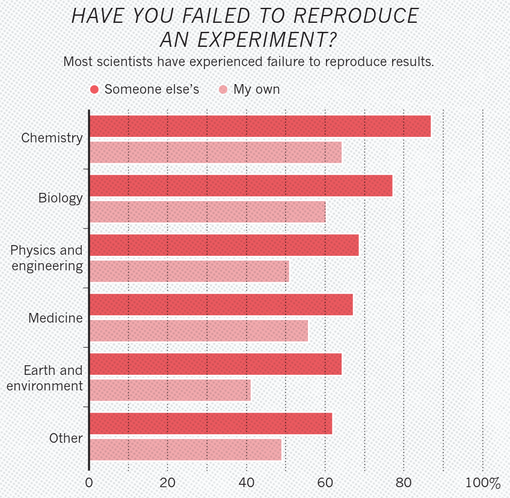

article

Baker, M. 1,500 scientists lift the lid on reproducibility. **Nature 533**, 452–454 (2016). https://doi.org/10.1038/533452a

African Brain Child | Neurosciences Institute | UCT

## 14 What contributes to the problem?

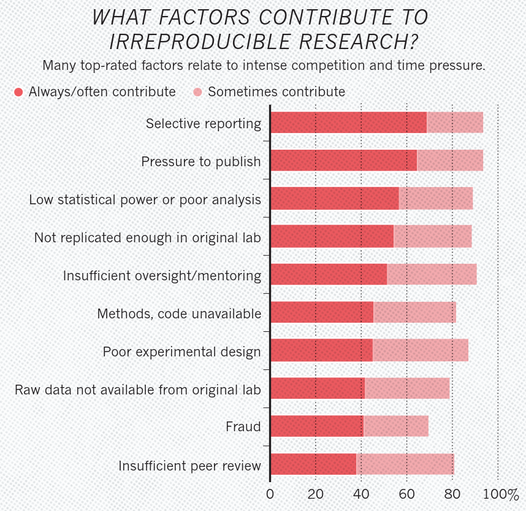

article

Baker, M. 1,500 scientists lift the lid on reproducibility. **Nature 533**, 452–454 (2016). https://doi.org/10.1038/533452a

African Brain Child | Neurosciences Institute | UCT

## 15 Issues that contribute to the replication crisis

edit_note

**Statistics, design**

- Low statistical power
- Researcher degrees of freedom / analytic flexibility
- *p*-hacking
- HARKing
- Misuse and misinterpretation of *p*-values
- Pseudoreplication
- Unit-of-analysis errors
- Low prior probability
- Analytic variability

**Publication, reporting**

- File drawer problem
- Publication bias
- Outcome switching
- Selective outcome reporting
- Spin & positive-result inflation
- Reporting errors
- Insufficient methodological detail

**Incentives, culture**

- Publish or perish
- Novelty bias
- Questionable research practices
- Fraud
- Poor training & mentoring

**Transparency, infrastructure**

- Data & code not shared
- Code that doesn’t run
- Undocumented analysis steps
- Manual, untraceable edits
- Quality of materials & reagents

**Other**

- Poor measurement validity
- Weak theory
- Hidden / lurking variables (confounders)
- True heterogeneity

**Solutions**

1. Analysis as code
2. Version control & env. mgt.
3. Preregistration
4. Open data, code, materials
5. Better design, statistics, reporting
6. Culture, incentives, training
7. Other

**Impact**

Prevents

Mitigates

Exposes

Needs other work

African Brain Child | Neurosciences Institute | UCT

## 16 What can we do?

edit_note

**Solutions**

**1**

Analysis as code

[interactive chart not shown]

**2**

Version control

[interactive chart not shown]

Env. mgt

[interactive chart not shown]

**3**

Preregistration

[interactive chart not shown]

**4**

Open data

[interactive chart not shown]

Open code

[interactive chart not shown]

Open materials

[interactive chart not shown]

**5**

Better design

[interactive chart not shown]

Better statistics

[interactive chart not shown]

Better reporting

[interactive chart not shown]

**6**

Culture

[interactive chart not shown]

Incentives

[interactive chart not shown]

Training

[interactive chart not shown]

**7**

Measurement validation

[interactive chart not shown]

Theory

[interactive chart not shown]

Multi-centre

[interactive chart not shown]

Multi-study

[interactive chart not shown]

Meta-analysis

[interactive chart not shown]

Let’s discuss what lies within our sphere of influence and what lies outside of it.

African Brain Child | Neurosciences Institute | UCT

## 17 What is code?

Recipe. Think lab notebook.

African Brain Child | Neurosciences Institute | UCT

## 18 Why code?

[interactive chart not shown]

edit_note

- Be kind the ‘future you’
- Open science. Transparency
- Scalability
- Collaboration
- Automation
- Some problems specific to point-and-click workflows

One part of the solution is have analysis be conducted using code which is stored, shared, version controlled, and correctly annotated.

African Brain Child | Neurosciences Institute | UCT

## 19 Gene name errors

[figure not shown]

[figure not shown]

African Brain Child | Neurosciences Institute | UCT

## 20 Gene name errors 2

article

- Ziemann, M., Eren, Y., & El-Osta, A. (2016). Gene name errors are widespread in the scientific literature. **Genome biology, 17**(1), 177. https://doi.org/10.1186/s13059-016-1044-7
- Abeysooriya, M., Soria, M., Kasu, M. S., & Ziemann, M. (2021). Gene name errors: Lessons not learned. **PLoS computational biology, 17**(7), e1008984. https://doi.org/10.1371/journal.pcbi.1008984

Excel gene-name errors (e.g., SEPT2 became a date) affected about 1 in 5 genomics papers with supplementary gene lists (Ziemann et al., 2016)

African Brain Child | Neurosciences Institute | UCT

## 21 Gene name errors 3

[figure not shown]

article

Bruford, E.A., Braschi, B., Denny, P. *et al*. Guidelines for human gene nomenclature. **Nat Genet 52**, 754–758 (2020). https://doi.org/10.1038/s41588-020-0669-3

Human Genome Organization (HUGO). HUGO Gene Nomenclature Committee (HGNC). Changed 27 gene names.

African Brain Child | Neurosciences Institute | UCT

## 22 COVID and NHS contact tracing

edit_note

- CSV file conversion
- ~16,000 positive COVID cases missed
- Contact tracing for ~50,000 people delayed
- Transmission believed to be flat

African Brain Child | Neurosciences Institute | UCT

## 23 Economics and austerity measures

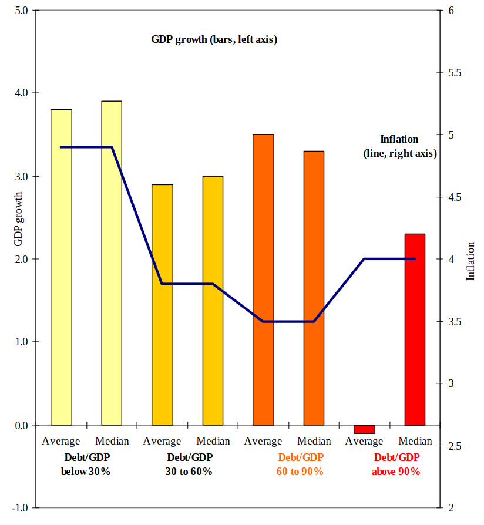

article

- Carmen M. Reinhart & Kenneth S. Rogoff, 2010. Growth in a Time of Debt, **American Economic Review 100**(2), p. 573-578

5 out of 20 selected countries were ommited when using the AVERAGE function (Australia, Austria, Belgium, Canada, and Denmark). The rest were Finland, France, Germany, Greece, Ireland, Italy, Japan, Netherlands, New Zealand, Norway, Portugal, Spain, Sweden, the United Kingdom, and the United States.

African Brain Child | Neurosciences Institute | UCT

## 24 Economics and austerity measures 2

article

- Carmen M. Reinhart & Kenneth S. Rogoff, 2010. Growth in a Time of Debt, **American Economic Review 100**(2), p. 573-578
- Herndon, Thomas, Ash, Michael and Pollin, Robert, (2014), Does high public debt consistently stifle economic growth? A critique of Reinhart and Rogoff, **Cambridge Journal of Economics, 38**, issue 2, p. 257-279

African Brain Child | Neurosciences Institute | UCT

## 25 Why NOT code?

edit_note

- Investment of time
- Dedicated workflows and infrastructure
- Collaborators use Excel or SPSS

There are legitimate reasons that prevent people from learning to code or adopting the general practice.

African Brain Child | Neurosciences Institute | UCT

## 26 What can code NOT fix?

edit_note

- Poor study design
- Poor data
- Unshared data
- Wrong code

There are legitimate reasons that prevent people from learning to code or adopting the general practice.

African Brain Child | Neurosciences Institute | UCT

## 27 Why R?

edit_note

- Just 1 of many options. In many cases, R isn’t the best
- Documentation
- Many peer-reviewed packages and functions
- Open-source
- Community and support
- What is the norm in your field?

R is one of many options for data analysis. Globally, python is more popular, particularly with people who have a computer science background or who are doing machine learning. R is more popular in academic circles (though python is catching up). Other options like Julia and Matlab are more niche but may be the best options for a specific application. R is particularly good because many of the functions, packages, and algorithms available have associated peer reviewed publications. The code is also open source, so one can verify internals if one wants to. All packages have documentation. There is a wide base of community support and some commercial support (like Posit). R is also particularly good for research-grade graphics.

African Brain Child | Neurosciences Institute | UCT

## 28 R is one part of an ecosystem

Who helps, and who maintains it?

**Community**

R Core Team, Stack Overflow, rOpenSci, user groups, GitHub issues, Posit Community, Posit

What runs my instructions?

**Engine**

R Language and compiler. The engine that does the computation. Desktop, cloud, UCT HPC.

Where do I work?

**Interface**

IDE: RStudio, Positron, VS Code, desktop or cloud

What does my work get saved in?

**Record**

Scripts or text files (.R, .qmd)

What can I do beyond the basics?

**Extend**

Packages, CRAN, Bioconductor, GitHub

Where does the information come from?

**Data**

UCT RDS, CSV, Excel, SPSS, databases, APIs

How does it become a paper or talk?

**Present**

Quarto, Markdown, Typst/LaTeX, Pandoc

Where does it live, and who sees it?

**Share**

Git, GitHub, OSF/Zenodo, Shiny, Docker

Data arrive

You write code

R runs it, using packages

Quarto weaves results and text into a document

Git records every change; GitHub shares it

To start, you need only two layers

## 29 R ecosystem

edit_note

- https://www.r-project.org/
- https://www.rousseeuwprize.org/2026/laureates
- https://cran.r-project.org/
- https://www.bioconductor.org/
- https://posit.co/
- https://shiny.posit.co/
- https://rmarkdown.rstudio.com/
- https://quarto.org/
- https://posit.co/products/ide/positron
- https://posit.co/products/open-source/rstudio
- https://github.com/

R fits well into a broader ecosystem whereby analysis code (R) sits alongside presentation code (LaTeX, Quarto, md, etc) so that code, output, text, figures all sit within a single document that can produce reports, journal articles, presentations, web pages, and several other output formats.

African Brain Child | Neurosciences Institute | UCT

## 30 Live presentation

[figure not shown]

https://petelaver.github.io/abc-introtor1/

African Brain Child | Neurosciences Institute | UCT

## 31 Public Github repository

[figure not shown]

https://github.com/PeteLaver/abc-introtor1

African Brain Child | Neurosciences Institute | UCT

## 32 Next steps: download and install R

[figure not shown]

https://www.r-project.org/

African Brain Child | Neurosciences Institute | UCT

## 33 Next steps: download and install RStudio (IDE)

[figure not shown]

https://posit.co/products/open-source/rstudio

African Brain Child | Neurosciences Institute | UCT

## 34 Next steps: next session

edit_note

**07/12/2026**

.

African Brain Child | Neurosciences Institute | UCT